# CS590 PopVar Example - Fall 2025

Jeanette Lyerly

2025-11-06

### Purpose

This is an example for predicting crosses in soft red winter wheat for a list of parents using a regional nursery training population.

A list of 2025 GAWN (Gulf Atlantic Wheat Nursery) lines will be the potential parents. We want to predict crosses with these lines and make some decisions about which crosses would be best.

We will use the `PopVar` package by Tyler Tiede, Jeffrey Neyhart (Maintainer), Mohsen Mohammadi, and Kevin Smith for prediction. Information about this package is available at https://cran.r-project.org/web/packages/PopVar/refman/PopVar.html (verified 11/6/2025).

### Libraries

Install libraries if needed.

```r
install.packages("tidyverse")
install.packages("rrBLUP")
install.packages("PopVar")
install.packages("knitr")
install.packages("kableExtra")
install.packages("here")
install.packages("psych")
```

Load libraries. We will use the `here` package to manage file paths. To use `here`, be sure you open the R project before opening this markdown. Learn more about `here` - https://here.r-lib.org.

```r
knitr::opts_chunk$set(echo = FALSE)

library(tidyverse)
library(rrBLUP)
library(PopVar)
library(knitr)
library(kableExtra)
library(here)
library(psych)
```

### Load the phenotype data

This phenotype data is taken from the GAWN (Gulf Atlantic Wheat Nursery) and Uniform Southern Soft Red Winter Wheat Scab Nursery (USF).

The GAWN is the most advanced of the four SunGrains wheat nurseries. It is evaluated at up to nine sites across the southeastern US, genotyped by the USDA-ARS Eastern Wheat Genotyping Lab, and subjected to genomic selection.

The USF provides multi-environment evaluations of FHB resistance for advanced generation breeding materials. The USF is evaluated at up to 11 locations in the US, genotyped by by the USDA-ARS Eastern Wheat Genotyping Lab, and also subjected to genomic selection.

Historical nursery data is curated and maintained for SunGrains by Jeanette Lyerly.

Phenotype data for this exercise is lsmeans for lines in these respective nurseries over environments (location + year), calculated prior to this exercise using `lme4` in R.

Data is stored in a csv file in the input files folder.

```
## Rows: 904
## Columns: 6
## $ ID         <chr> "LA066", "NC071", "VA027", "AR074", "VA009", "VA107", "VA11…
## $ Yield      <dbl> NA, NA, NA, 72.09879, 73.26301, NA, NA, NA, NA, 62.72569, 5…
## $ TestWt     <dbl> NA, NA, NA, 58.10580, 57.23162, NA, NA, NA, NA, 57.51366, 5…
## $ FDK        <dbl> 6.859460, 7.803393, 9.706824, 10.639166, 10.779166, 11.0367…
## $ DON        <dbl> 4.138802, 7.505727, 6.512142, 6.673091, 7.383091, 8.539060,…
## $ StripeRust <dbl> NA, NA, NA, 1.7409787, 1.3687252, NA, NA, NA, NA, 1.4158323…
```

Here we have a variable called “ID” and data for five traits - yield (bu per acre), test weight (lbs per bu), Fusarium damaged kernels (FDK percent), deoxynivalenol (DON ppm), and stripe rust (0-9 rating).

### Load the genotype data

Genotype data are SNP generated through genotyping-by-sequencing (GBS) for use in genomic selection. SNP are filtered for minor allele frequency, heterozygosity, and missing data. After filtering, missing data was imputed with Beagle.

Learn more about Beagle at B L Browning, X Tian, Y Zhou, and S R Browning (2021) Fast two-stage phasing of large-scale sequence data. Am J Hum Genet 108(10):1880-1890. doi:10.1016/j.ajhg.2021.08.005.

A subset of about 4000 SNP was generated for this exercise, coded as 0, 1, and 2.

```
##      ID S1A_001 S1A_002 S1A_003 S1A_004
## 1 GA181       0       0       0       0
## 2 VA033       0       2       0       0
## 3 AR065       0       0       0       0
## 4 GA002       0       2       0       0
## 5 FL031       0       0       0       0
```

Again, we have a variable called “ID” and some genotype data. SNP are labeled with chromosome and order information - S1A_001 is the first SNP on chromsome 1A, etc.

In this format, 0 is the major allele, 1 is a heterozygote, and 2 is the minor allele for each SNP.

### Data exploration

For predicting your own crosses, you would already be familiar with your data. Since we are loading unfamiliar data for this exercise, it’s a good idea to look at the data and make sure it looks correct and we understand it.

**Always look at your data!**

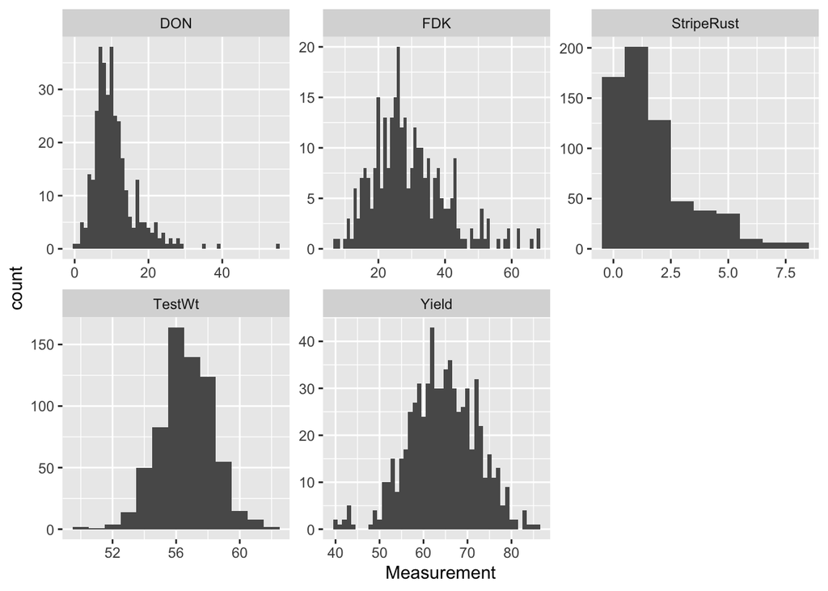

Yield and test weight look pretty normal. Same for FDK. DON has some skew, with a few samples showing very high levels of DON toxin in the tested grain. Stripe rust has a larger percentage of lines with low values, but we do have some lines that are susceptible to stripe rust.

**Questions:**

- What would happen if you didn’t set the scales to free for this plot?
- If you observed something odd in your data, such as a value far outside the distribution, what might that mean? How would you fix it?

### Relationships among traits

Are there any correlations among these traits that we need to keep in mind when considering crosses?

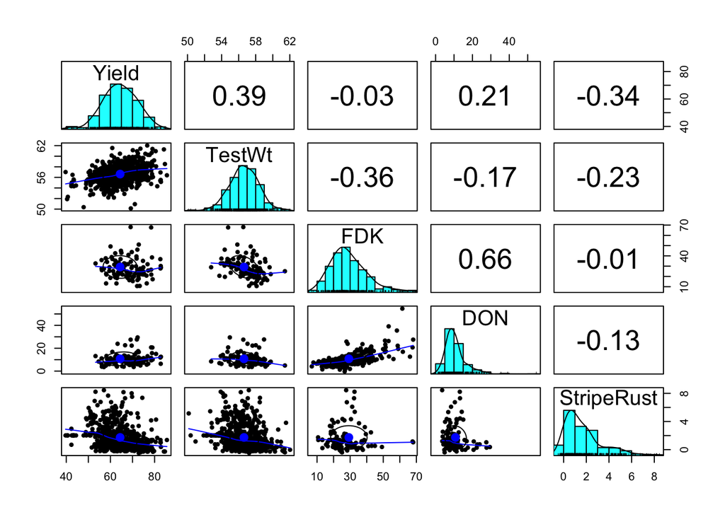

Yield and test weight are positively correlated, which is not unexpected.  
FDK and DON are also positively correlated.

**Questions:**

- What about our disease traits? We can see some negative relationships here.
- Do we need to consider this in our crossing plan?

### Formatting

To use the SNP data for this package we need to have it coded as -1, 0, 1.

```
## [1]  904 4075
```

We have about 4000 SNP in this data set to work with.

### Load the map

In order to run `PopVar` you need a map with cM positions. This map is associated with the example genotype file and has cM and SNP positions.

```
## [1] TRUE
```

The map and the genotype data need to be in the same order. In this case the value returns TRUE, so this is correct.

**Questions:**

- If these were not in the correct order what function(s) could you use to fix it?

### Load the list of parents to use

For this example we have selected a list of potential parents. These lines will have genotype data, but all of them may not have phenotype data.

```
## Rows: 30
## Columns: 2
## $ ID   <chr> "GA001", "GA002", "GA159", "GA164", "LA136", "LA137", "LA143", "L…
## $ EXPT <chr> "CB25", "CB25", "CB25", "CB25", "CB25", "CB25", "CB25", "CB25", "…
```

### Add the parents to the phenotype data

The parents may not all have phenotype data. Why or why not?

We have a data set where some samples have phenotype data, and some do not. We can also see that in our historical data some lines have data for traits and others do not. This is typical of historical data, where every location/year may not have been able to collect data for a trait.

### Check phenotype and genotype data

Our genotype and phenotype data frames need to match with the same samples. If a sample doesn’t have genotype data (plant didn’t grow, etc) then we need to remove it from the data set - we will not be able to predict it.

```
## [1] 904   7
```

```
## [1] 904   7
```

Our list of parents has 30 lines. We want to predict crosses for this set of 30.

### Look at the marker distributions

Here we will look at the marker distribution over the data set. We want this to be representative - if you are thinning the SNP set or selecting markers it’s always a good idea to check your distributions.

Wheat has A, B, and D genomes with chromosomes 1 - 7 (1A, 2A, 3A, etc. to 7D). To make these plots easier to read we are going to group them by chromosome.

We can use ggsave to save these plots of we want to look at them later.

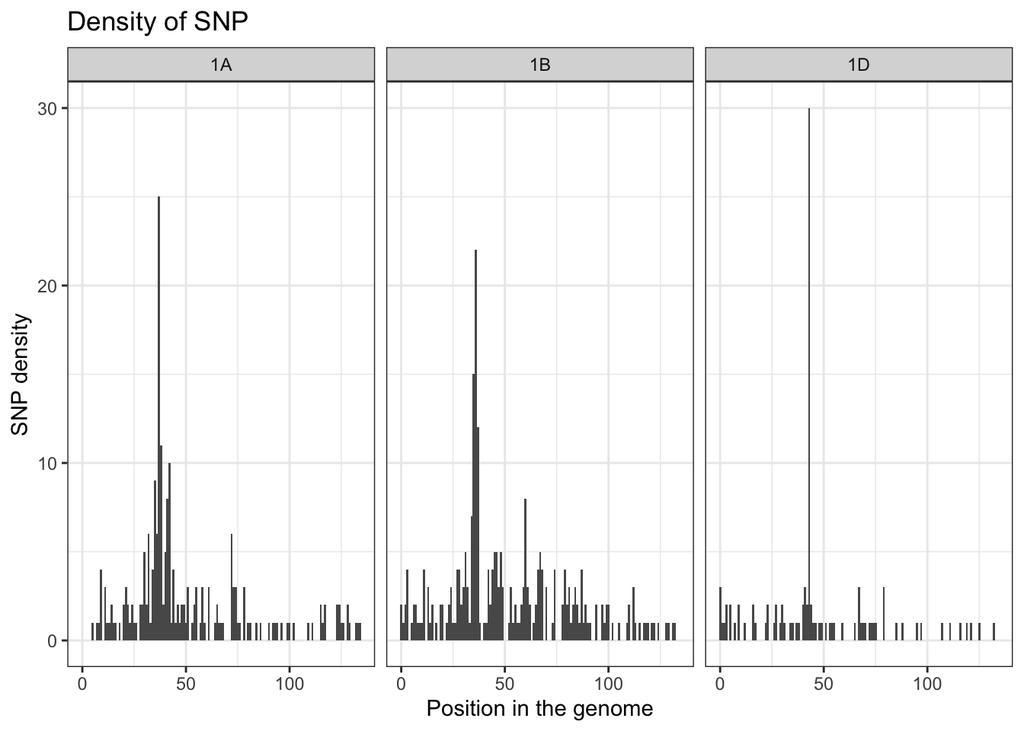

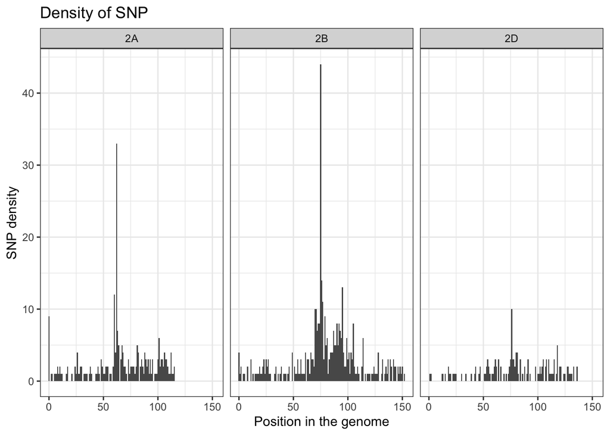

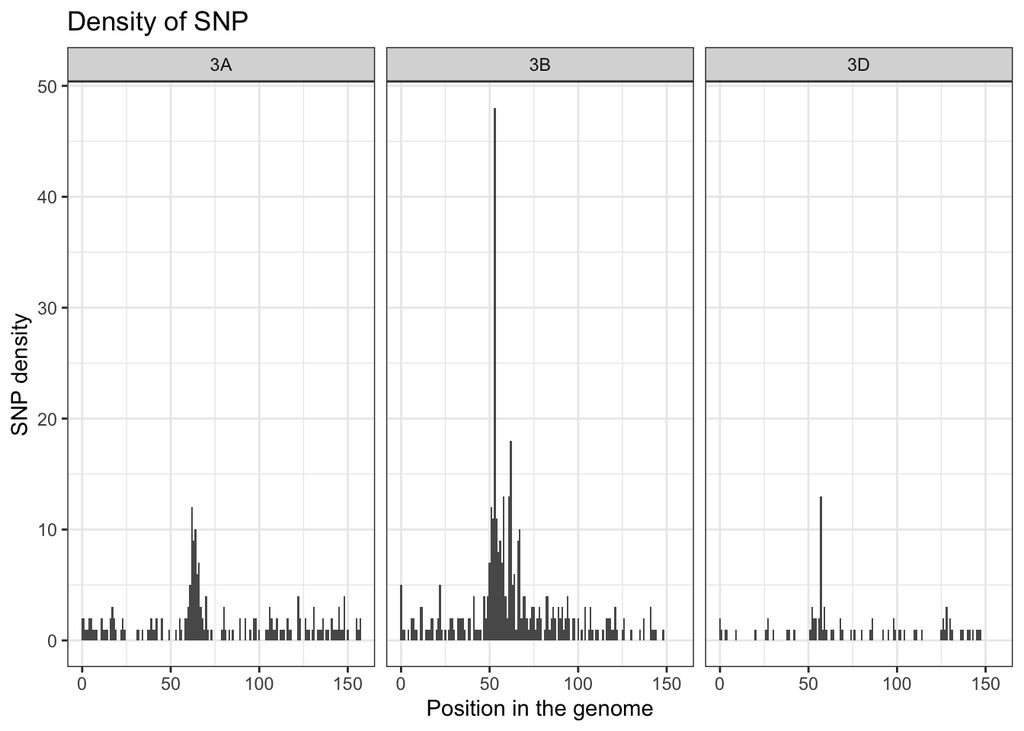

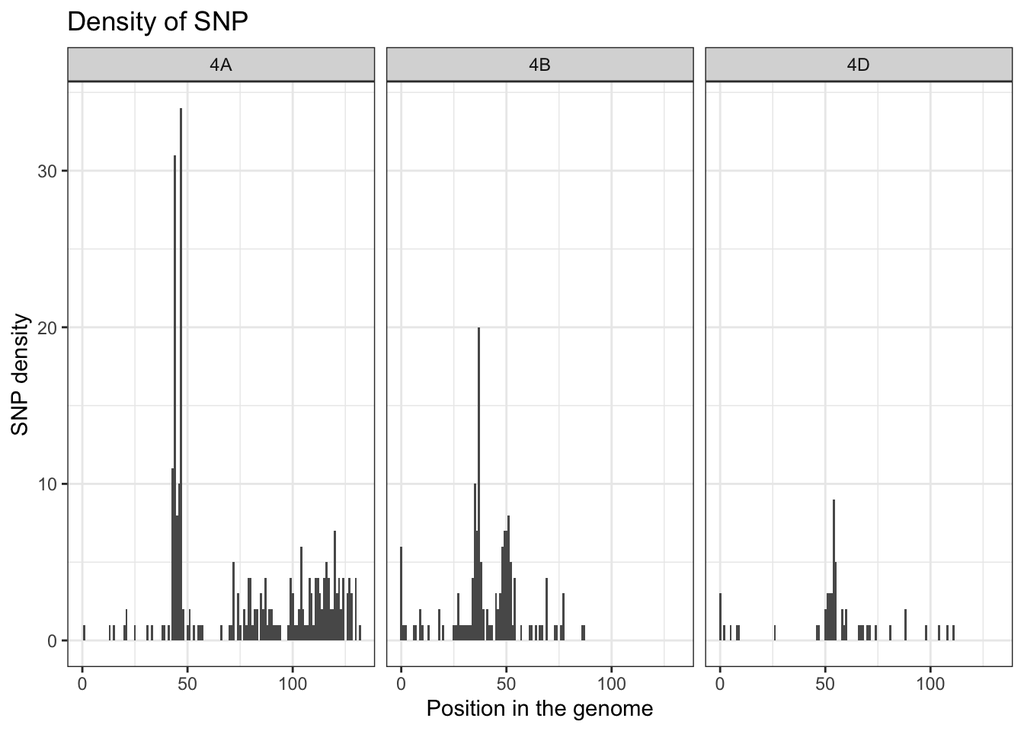

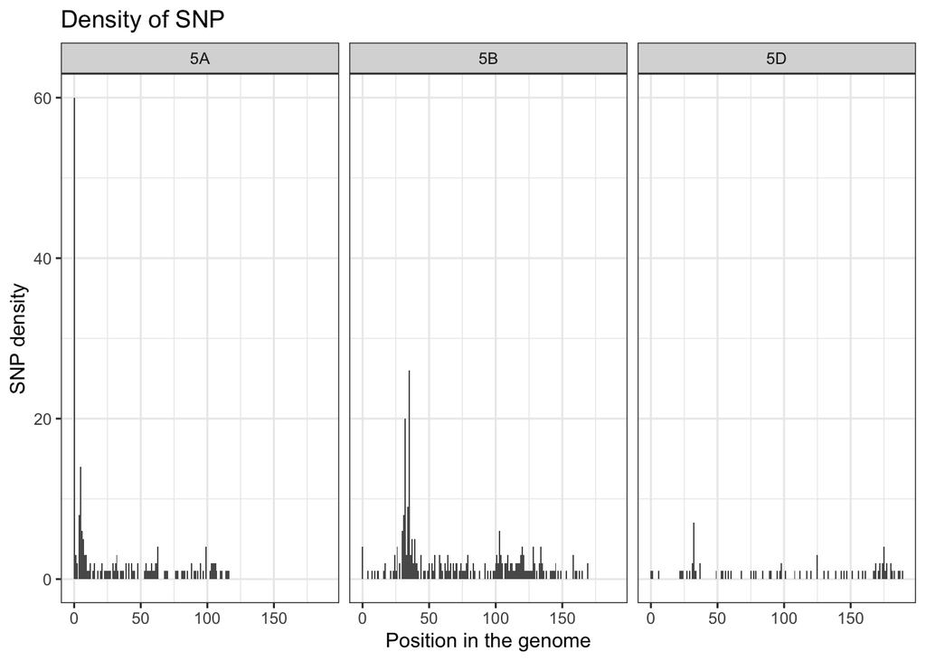

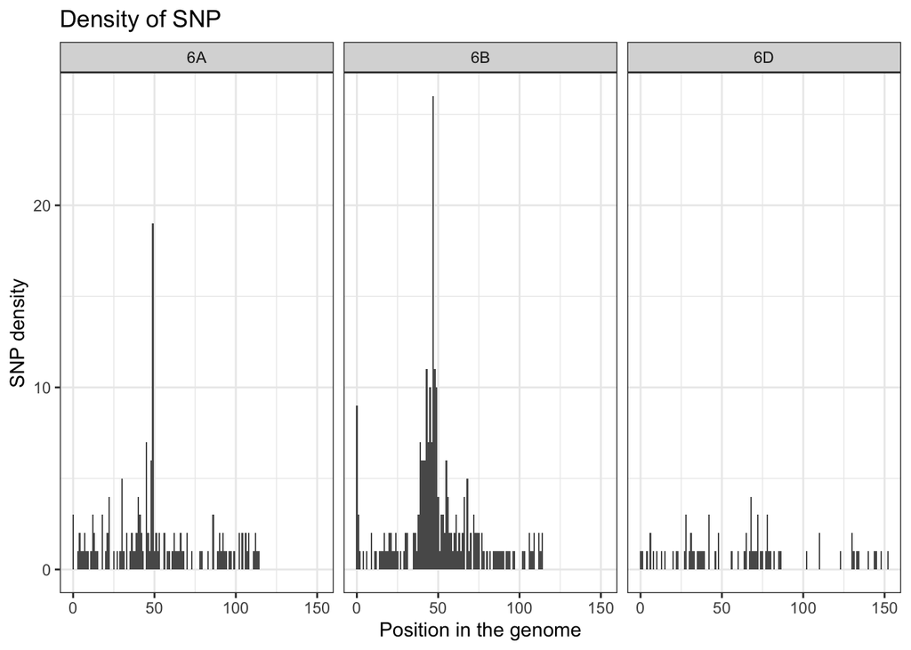

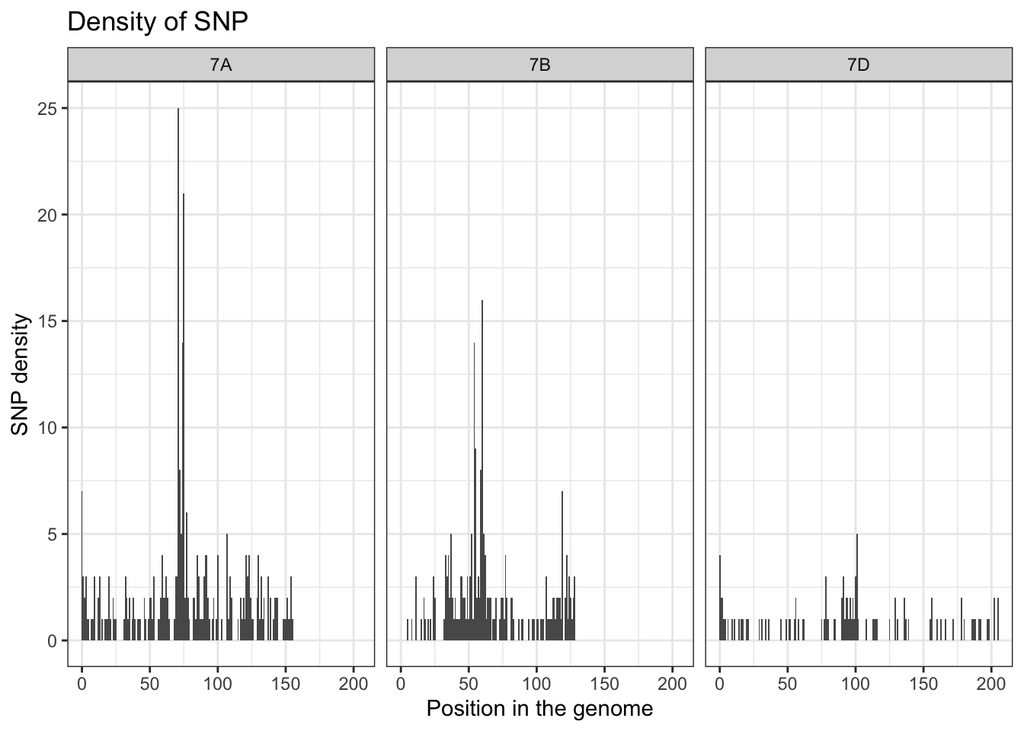

We will also run a marker count.

| chr | n |
| --- | --- |
| 1A | 212 |
| 1B | 261 |
| 1D | 103 |
| 2A | 242 |
| 2B | 408 |
| 2D | 142 |
| 3A | 192 |
| 3B | 375 |
| 3D | 82 |
| 4A | 256 |
| 4B | 144 |
| 4D | 53 |
| 5A | 197 |
| 5B | 265 |
| 5D | 79 |
| 6A | 147 |
| 6B | 246 |
| 6D | 73 |
| 7A | 283 |
| 7B | 213 |
| 7D | 101 |

Based on the counts 4D has the lowest numbers. Fewer markers for the D chromosomes is typical for winter wheat.

### Subset markers

All the markers could be used, or you can make a smaller subset for `PopVar`. The run time will be longer for a larger number of markers. In this example we will make a subset for the sake of time, but you could also try them all as an additional exercise.

Here we will make a subset of markers.

**Questions:**

- How many markers is enough?
- How might you decide?

```
## [1] TRUE
```

```
## [1] TRUE
```

```
##
## 1A 1B 1D 2A 2B 2D 3A 3B 3D 4A 4B 4D 5A 5B 5D 6A 6B 6D 7A 7B 7D
## 29 30 10 21 55 17 25 57 14 26 19  8 25 33  7 16 32 12 34 23  7
```

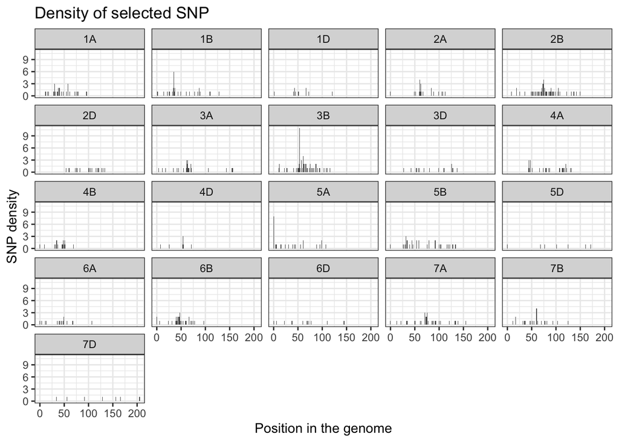

It’s a good idea to look at your distribution before proceeding. The number of markers you choose will depend on your genome, coverage, and goals for the experiment.

## Format data and run PopVar

The formatting is a little picky in that `PopVar` wants the marker matrix to have the names of taxa and markers **in the matrix itself** rather than as row names and column names.

Each simulated population will have 200 individuals (nInd) and we will have 25 iterations for each pairwise cross (nSim).

```
## Selecting best model via cross validation for Yield and estimating marker effects...
```

```
## Cross validation is complete!
```

```
##
## Brewing 25 populations of 200 individuals for each cross... Please be patient
```

### Troubleshooting

Sometimes the formatting trips people up, even for code that ran before. Package updates and changes to functions can result in errors. Things to check:  
- Are the genotype data and the map in the same order?  
- Are all the lines in the phenotype file in the genotype file?  
- Do the line names match?  
- Are all your input structures data frames?

### Look at the output

In this example we’ve generated all possible crosses with the parents in our list.

What does out output look like?

| Par1 | Par2 | midPar.Pheno | midPar.GEBV | pred.mu | pred.mu_sd | pred.varG | pred.varG_sd | mu.sp_low | mu.sp_high |
| --- | --- | --- | --- | --- | --- | --- | --- | --- | --- |
| GA001 | GA002 | NaN | 67.60 | 67.66 | 0.13 | 3.94 | 0.29 | 64.18 | 71.09 |
| GA001 | GA159 | NaN | 68.88 | 68.92 | 0.12 | 4.90 | 0.49 | 65.03 | 72.71 |
| GA001 | GA164 | NaN | 68.18 | 68.24 | 0.18 | 6.02 | 0.51 | 63.95 | 72.48 |
| GA001 | LA136 | NaN | 71.28 | 71.32 | 0.16 | 4.11 | 0.42 | 67.80 | 74.88 |
| GA001 | LA137 | NaN | 72.09 | 72.16 | 0.14 | 4.74 | 0.41 | 68.40 | 75.92 |
| GA001 | LA143 | NaN | 65.77 | 65.72 | 0.12 | 3.26 | 0.28 | 62.54 | 68.78 |
| GA001 | LA144 | NaN | 68.44 | 68.48 | 0.14 | 4.45 | 0.46 | 64.82 | 72.16 |
| GA001 | MD001 | NaN | 69.41 | 69.40 | 0.12 | 5.14 | 0.60 | 65.48 | 73.33 |
| GA001 | MD002 | NaN | 70.73 | 70.79 | 0.16 | 4.23 | 0.40 | 67.27 | 74.35 |
| GA001 | MD033 | NaN | 67.56 | 67.58 | 0.15 | 3.81 | 0.32 | 64.14 | 70.94 |

We have some GEBV values, a mean and variance for the simulated populations for each cross, and statistics for the mean of the lowest 10% and the highest 10% from those simulated populations.

How many crosses do we have?

```
## [1] 435
```

We have results for 435 crosses. We probably don’t want to make that many. We could sort our output data frame to decide which ones we might like best.

We could look at the best crosses using the predicted mean of the population, the variance, and the mean of the highest 10% for each population.

| Par1 | Par2 | pred.mu | pred.varG | mu.sp_high |
| --- | --- | --- | --- | --- |
| TX023 | VA028 | 74.80 | 6.30 | 79.08 |
| LA137 | TX023 | 74.60 | 4.40 | 78.31 |
| SC004 | TX023 | 74.36 | 4.39 | 77.98 |
| NC120 | TX023 | 74.32 | 5.25 | 78.22 |
| TX023 | VA029 | 74.24 | 6.40 | 78.59 |
| LA137 | VA028 | 74.15 | 4.04 | 77.66 |
| SC005 | TX023 | 74.06 | 4.96 | 77.93 |
| TX021 | TX023 | 74.01 | 5.29 | 78.06 |
| SC004 | VA028 | 73.92 | 6.72 | 78.40 |
| NC120 | VA028 | 73.86 | 5.44 | 77.86 |

**Questions:**

- Which crosses would you select?
- Why or why not?

### How can we use these results?

Now we have our cross predictions - what can we do with them?

- Review the crosses that are suggested - are there combinations in here we didn’t expect?
- Look at the parents that are often selected in the best (highest yielding, etc) crosses (whatever best means to us) - do we expect these parents to have good combining ability or sets of desirable alleles?

### Multiple traits

It’s good to generate crosses with high yield, but realistically we care about other traits in addition to yield. Let’s run the same exercise using more than one trait.

```
## Selecting best model via cross validation for Yield and estimating marker effects...
```

```
## Selecting best model via cross validation for DON and estimating marker effects...
```

```
## Cross validation is complete!
```

```
##
## Brewing 25 populations of 200 individuals for each cross... Please be patient
```

This generates output for crosses for yield and DON.

### How can we use these results?

Now we have our cross predictions for two traits - how can we use those results?

- Subset our list of crosses to see what parents are predicted to give us high yield and low DON, perhaps we also want to visualize that.

| Parent1 | Parent2 | Yield_param.df.pred.mu | Yield_param.df.pred.varG | Yield_param.df.mu.sp_high | DON_param.df.midPar.GEBV | DON_param.df.pred.varG | DON_param.df.mu.sp_low | best |
| --- | --- | --- | --- | --- | --- | --- | --- | --- |
| TX023 | VA028 | 74.78 | 6.01 | 79.04 | 9.72 | 2.28 | 7.12 | no |
| LA137 | TX023 | 74.56 | 4.29 | 78.14 | 13.72 | 0.88 | 12.11 | no |
| NC120 | TX023 | 74.31 | 5.22 | 78.15 | 12.59 | 1.17 | 10.71 | no |
| SC004 | TX023 | 74.29 | 4.38 | 77.88 | 12.81 | 1.71 | 10.58 | no |
| TX023 | VA029 | 74.20 | 6.14 | 78.48 | 11.06 | 1.63 | 8.89 | no |
| LA137 | VA028 | 74.09 | 3.97 | 77.56 | 9.14 | 2.37 | 6.49 | no |
| SC005 | TX023 | 74.07 | 4.96 | 78.00 | 10.85 | 1.82 | 8.50 | no |
| TX021 | TX023 | 73.94 | 5.01 | 77.83 | 14.62 | 0.88 | 12.99 | no |
| NC120 | VA028 | 73.85 | 5.45 | 77.85 | 8.01 | 1.66 | 5.82 | yes |
| TX023 | VA031 | 73.84 | 6.52 | 78.28 | 10.85 | 1.85 | 8.51 | no |

**Questions:**

- Which crosses would you select from this table?
- Why or why not?

### Bonus: Visualize the best crosses for two traits

Visualize two traits using the predicted mean of the crosses.  
Highlight the values for the crosses you are most interested in.  
Make a table with those crosses.

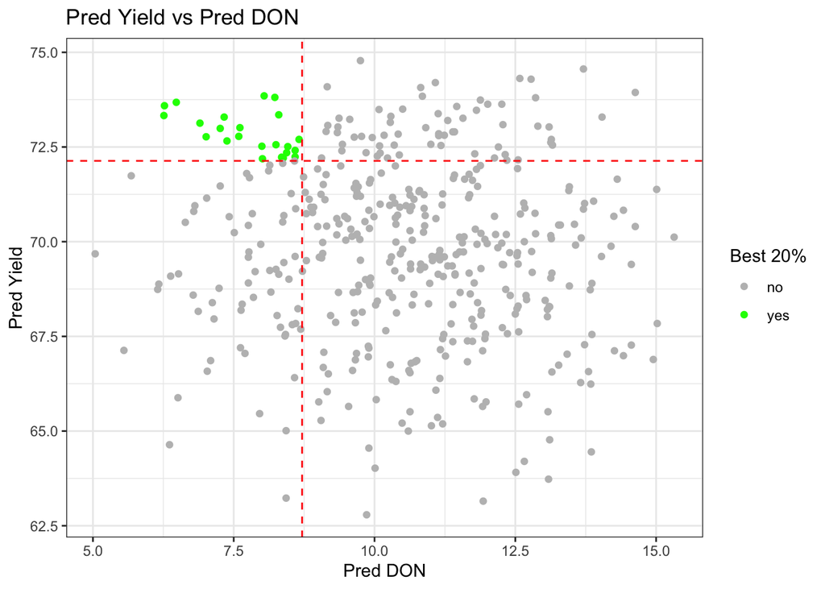